# Part II - Communicating findings about the prosper loan dataset

## by Ghea Sandrine Mawen

## Investigation Overview

> As a potential borrower, I was very curious to learn about: what affects the interest rates of loans, How the prosper score acts as a determinant to the loan amount and interest rate, What size of loans do customers on Prosper often take out? Who takes on large loans? Who recieves small loans?

## Dataset Overview

> The Prosper Loan Dataset is the one used for this project. The dataset includes information on the specifics of the numerous loans made to borrowers by Prosper. The Listing Key serves as a unique identifier for each loan represented by a row in the dataset. The dataset's rows each indicate a different characteristic of the borrower, such as employment status, credit score, etc. Other factors like Monthly Payments, On-Time Payments, Interest Rate, etc. are also stated in each row.

## (Visualization 1)

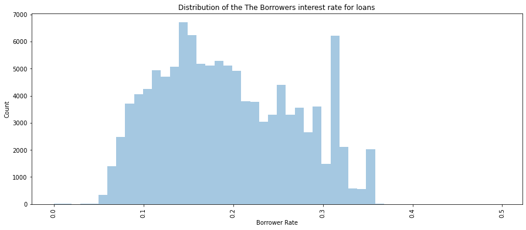

## Does Higher Income Lead to Higher Prosper Scores ?

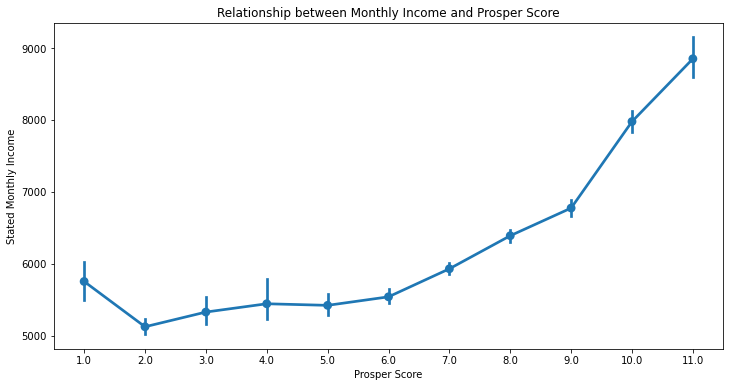

## Relationship between home ownership lead to Higher Prosper Score ?

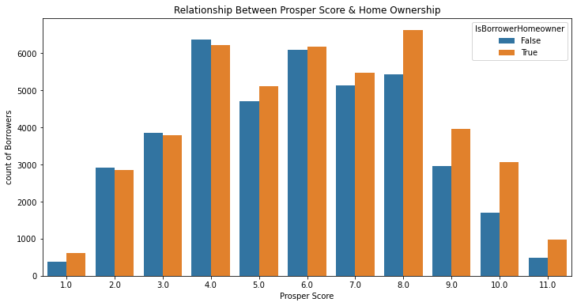

## Does the Interest Rate depend on Borrower's Prosper Score ?

A High negative Correlation can be observed between the Interest Rate and Borrower's Prosper Score. Relationship: Higher prosper score -> Lower Interest Rate and vice-versa.

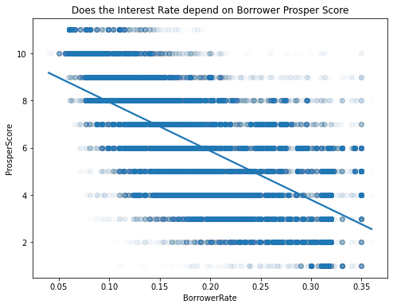

## How does Borrower's Employment affect the Loan Interest Rate ?

A clear relationship can be observed between Borrower's Employment and Loan Interest Rate. Borrower's who are Not Employed, have been charged the Highest Interest Rate, where borrowers who are Employed Full-Time/Part-Time are offered the minimum Interest Rate.

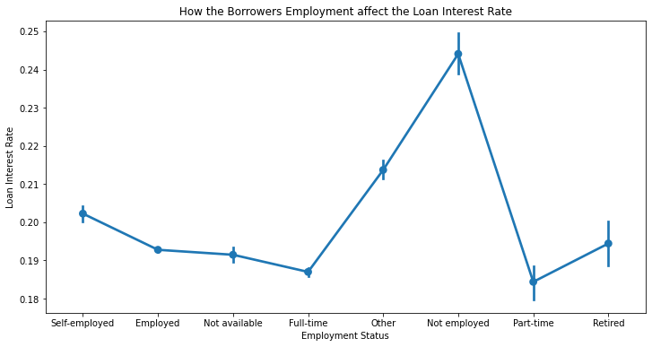

## how does borrower APR relates to loan original amount

This shows there's a negative correlation between borrower APR and loan original amount. Relationship: Higher Loan Original Amount -> Lower Interest Rate and vice-versa.

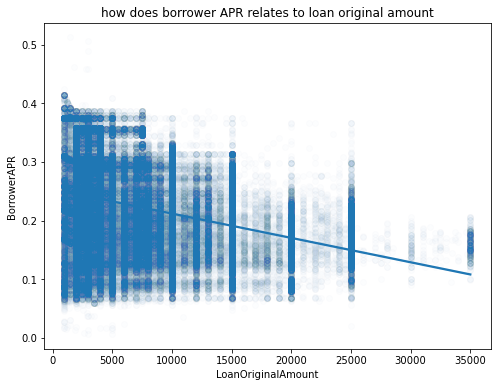

## Prosper rating effect on relationship of APR and loan amount

The loan amount increases with better rating. The borrower APR decreases with better rating. Interestingly, the relationship between borrower APR and loan amount turns from negative to slightly positive when the Prosper ratings are increased from HR to A or better. This may because people with A or AA ratings tend to borrow more money, increasting APR could prevent them borrow even more and maximize the profit. But people with lower ratings tend to borrow less money, decreasing APR could encourage them to borrow more.

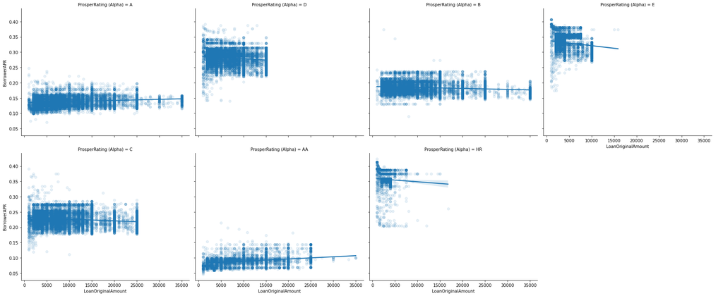

[output not shown]

[output not shown]

[output not shown]

[output cut: 71 more lines]

[output not shown]